# DATA MEMO

Zhimei_Chen

2022-12-11

### Libraries Needed:

### DATA

#### Credit Card Approval Prediction

https://www.kaggle.com/datasets/rikdifos/credit-card-approval-prediction?select=application_record.csv  
application_record.csv contains appliers personal information, which I use as features for predicting.  
credit_record.csv records users’ behaviors of credit card.

### read csv and clean

```
## # A tibble: 6 × 18
##        id code_gender flag_own_car flag_own_realty cnt_children amt_income_total
##     <dbl> <chr>       <chr>        <chr>                  <dbl>            <dbl>
## 1 5008804 M           Y            Y                          0           427500
## 2 5008805 M           Y            Y                          0           427500
## 3 5008806 M           Y            Y                          0           112500
## 4 5008808 F           N            Y                          0           270000
## 5 5008809 F           N            Y                          0           270000
## 6 5008810 F           N            Y                          0           270000
##   name_income_type     name_education_type           name_family_status
##   <chr>                <chr>                         <chr>
## 1 Working              Higher education              Civil marriage
## 2 Working              Higher education              Civil marriage
## 3 Working              Secondary / secondary special Married
## 4 Commercial associate Secondary / secondary special Single / not married
```

[output cut: 18 more lines]

### DATA: application_data

#### Observations

```r
cat("Observation number in application: ", nrow(application))
```

```
## Observation number in application:  438557
```

#### turn to characters and factors and see if there are NAs

```
##       id            code_gender flag_own_car flag_own_realty  cnt_children
##  Length:438557      F:294440    N:275459     N:134483        Min.   : 0.0000
##  Class :character   M:144117    Y:163098     Y:304074        1st Qu.: 0.0000
##  Mode  :character                                            Median : 0.0000
##                                                              Mean   : 0.4274
##                                                              3rd Qu.: 1.0000
##                                                              Max.   :19.0000
##
##  amt_income_total              name_income_type
##  Min.   :  26100   Commercial associate:100757
##  1st Qu.: 121500   Pensioner           : 75493
##  Median : 160780   State servant       : 36186
##  Mean   : 187524   Student             :    17
##  3rd Qu.: 225000   Working             :226104
##  Max.   :6750000
##
##                     name_education_type            name_family_status
##  Academic degree              :   312   Civil marriage      : 36532
##  Higher education             :117522   Married             :299828
##  Incomplete higher            : 14851   Separated           : 27251
##  Lower secondary              :  4051   Single / not married: 55271
##  Secondary / secondary special:301821   Widow               : 19675
##
##
##            name_housing_type    days_birth     days_employed    flag_mobil
##  Co-op apartment    :  1539   Min.   :-25201   Min.   :-17531   1:438557
##  House / apartment  :393831   1st Qu.:-19483   1st Qu.: -3103
##  Municipal apartment: 14214   Median :-15630   Median : -1467
##  Office apartment   :  3922   Mean   :-15998   Mean   : 60564
##  Rented apartment   :  5974   3rd Qu.:-12514   3rd Qu.:  -371
##  With parents       : 19077   Max.   : -7489   Max.   :365243
##
##  flag_work_phone flag_phone flag_email    occupation_type   cnt_fam_members
##  0:348156        0:312353   0:391102   Laborers   : 78240   Min.   : 1.000
##  1: 90401        1:126204   1: 47455   Core staff : 43007   1st Qu.: 2.000
##                                        Sales staff: 41098   Median : 2.000
##                                        Managers   : 35487   Mean   : 2.194
##                                        Drivers    : 26090   3rd Qu.: 3.000
##                                        (Other)    : 80432   Max.   :20.000
##                                        NA's       :134203
```

The only variable with missingness is occupation_type, which is missing 134203 observations.

#### Trans NA to “Dont wanna tell”

```r
application$occupation_type[is.na(application$occupation_type)] <- "Don't wanna tell"
```

#### turn to characters and factors

```
## # A tibble: 6 × 18
##   id      code_gender flag_own_car flag_own_realty cnt_children amt_income_total
##   <chr>   <fct>       <fct>        <fct>                  <dbl>            <dbl>
## 1 5008804 M           Y            Y                          0           427500
## 2 5008805 M           Y            Y                          0           427500
## 3 5008806 M           Y            Y                          0           112500
## 4 5008808 F           N            Y                          0           270000
## 5 5008809 F           N            Y                          0           270000
## 6 5008810 F           N            Y                          0           270000
##   name_income_type     name_education_type           name_family_status
##   <fct>                <fct>                         <fct>
## 1 Working              Higher education              Civil marriage
## 2 Working              Higher education              Civil marriage
## 3 Working              Secondary / secondary special Married
## 4 Commercial associate Secondary / secondary special Single / not married
```

[output cut: 18 more lines]

#### Variables

**id**: Client number  
**code_gender**: Gender [M,F]  
**flag_own_car**: Is there a car [N,Y]  
**flag_own_realty**: Is there a property [N,Y]  
**cnt_children**: Number of children  
**amt_income_total**: Annual income  
**name_income_type**: Income category [Commercial associate, Pensioner, State servant, Student, Working]  
**name_education_type**: Education level [Academic degree, Higher education, Incomplete higher, Lower secondary, Secondary / secondary special]  
**name_family_status**: Marital status [Civil marriage, Married, Separated, Single / not married, Widow]  
**name_housing_type**: Way of living [Co-op apartment, House / apartment, Municipal apartment, Office apartment, Rented apartment, With parents]  
**days_birth**: Birthday Count backwards from current day (0), -1 means yesterday  
**days_employed**: Start date of employment Count backwards from current day(0). If positive, it means the person currently unemployed.  
**flag_mobile**: Is there a mobile phone [0,1]  
**flag_work_phone**: Is there a work phone [0,1]  
**flag_phone**: Is there a phone [0,1]  
**flag_email**: Is there an email [0,1]  
**occupation_type**: Occupation [Laborers, Core staff, Sales staff, Managers, Drivers, (Other) , NA’s]  
**cnt_fam_members**: Family size

#### trans inappropriate days of employees to 0 days

```r
application$days_employed[application$days_employed==0] ##no one get 0 days
```

```
## numeric(0)
```

```r
head(application$days_employed[application$days_employed>0])
```

```
## [1] 365243 365243 365243 365243 365243 365243
```

```r
#Therefore, I think who don't have work has assigned as "365243" days
#trans the number of inappropriate days of employees to 0 days
application$days_employed[application$days_employed == 365243] <- 0
```

### DATA: credit_data

```r
head(credit)
```

```
## # A tibble: 6 × 3
##        id months_balance status
##     <dbl>          <dbl> <chr>
## 1 5001711              0 X
## 2 5001711             -1 0
## 3 5001711             -2 0
## 4 5001711             -3 0
## 5 5001712              0 C
## 6 5001712             -1 C
```

```r
summary(credit)
```

```
##        id          months_balance      status
##  Min.   :5001711   Min.   :-60.00   Length:1048575
##  1st Qu.:5023644   1st Qu.:-29.00   Class :character
##  Median :5062104   Median :-17.00   Mode  :character
##  Mean   :5068286   Mean   :-19.14
##  3rd Qu.:5113856   3rd Qu.: -7.00
##  Max.   :5150487   Max.   :  0.00
```

There is no missing data in credit.

#### Variables

id: Client number  
months_balance: Record month The month of the extracted data is the starting point, backwards, 0 is the current month, -1 is the previous month, and so on  
status: Status (*more in “transfer status”*)

#### Observations

```r
cat("Observation number in credit: ",nrow(credit))
```

```
## Observation number in credit:  1048575
```

#### transfer status

0: 1-29 days past due –> 1  
1: 30-59 days past due –> 2  
2: 60-89 days overdue –> 3  
3: 90-119 days overdue –> 4  
4: 120-149 days overdue –> 5  
5: Overdue or bad debts, write-offs for more than 150 days –> 6  
C: paid off that month –> 0  
X: No loan for the month –> 0

```
## # A tibble: 6 × 3
##   id      months_balance status
##   <chr>            <dbl> <chr>
## 1 5001711              0 0
## 2 5001711             -1 1
## 3 5001711             -2 1
## 4 5001711             -3 1
## 5 5001712              0 0
## 6 5001712             -1 0
```

#### turn to factors

```r
credit_needed <- credit_needed %>%
  mutate(status = factor(status))
head(credit_needed)
```

```
## # A tibble: 6 × 3
##   id      months_balance status
##   <chr>            <dbl> <fct>
## 1 5001711              0 0
## 2 5001711             -1 1
## 3 5001711             -2 1
## 4 5001711             -3 1
## 5 5001712              0 0
## 6 5001712             -1 0
```

first year credit

```r
first_year_credit <- credit_needed %>%
             arrange(id,months_balance,status) %>%
             group_by(id) %>%
             slice(1:12) %>%
             mutate(month = seq(1:length(id)))

head(first_year_credit)
```

```
## # A tibble: 6 × 4
## # Groups:   id [2]
##   id      months_balance status month
##   <chr>            <dbl> <fct>  <int>
## 1 5001711             -3 1          1
## 2 5001711             -2 1          2
## 3 5001711             -1 1          3
## 4 5001711              0 0          4
## 5 5001712            -18 1          1
## 6 5001712            -17 1          2
```

### Combine two datasets

#### How we combine?

Example

An example here who, with ID: 5008805, applied credit card and had been approved.

```r
first_year_credit[first_year_credit$id == 5008805,]
```

```
## # A tibble: 12 × 4
## # Groups:   id [1]
##    id      months_balance status month
##    <chr>            <dbl> <fct>  <int>
##  1 5008805            -14 0          1
##  2 5008805            -13 1          2
##  3 5008805            -12 2          3
##  4 5008805            -11 0          4
##  5 5008805            -10 0          5
##  6 5008805             -9 0          6
##  7 5008805             -8 0          7
##  8 5008805             -7 0          8
##  9 5008805             -6 0          9
## 10 5008805             -5 0         10
## 11 5008805             -4 0         11
## 12 5008805             -3 0         12
```

```r
credit[credit$id == 5008805,]
```

```
## # A tibble: 15 × 3
##         id months_balance status
##      <dbl>          <dbl> <chr>
##  1 5008805              0 C
##  2 5008805             -1 C
##  3 5008805             -2 C
##  4 5008805             -3 C
##  5 5008805             -4 C
##  6 5008805             -5 C
##  7 5008805             -6 C
##  8 5008805             -7 C
##  9 5008805             -8 C
## 10 5008805             -9 C
## 11 5008805            -10 C
## 12 5008805            -11 C
## 13 5008805            -12 1
## 14 5008805            -13 0
## 15 5008805            -14 X
```

```r
application[application$id == 5008805,]
```

```
## # A tibble: 1 × 18
##   id      code_gender flag_own_car flag_own_realty cnt_children amt_income_total
##   <chr>   <fct>       <fct>        <fct>                  <dbl>            <dbl>
## 1 5008805 M           Y            Y                          0           427500
##   name_income_type name_education_type name_family_status name_housing_type
##   <fct>            <fct>               <fct>              <fct>
## 1 Working          Higher education    Civil marriage     Rented apartment
##   days_birth days_employed flag_mobil flag_work_phone flag_phone flag_email
##        <dbl>         <dbl> <fct>      <fct>           <fct>      <fct>
## 1     -12005         -4542 1          1               0          0
##   occupation_type  cnt_fam_members
##   <fct>                      <dbl>
## 1 Don't wanna tell               2
```

Therefore, we can combine application data with first year, first month credit data

```r
length(unique(first_year_credit$id))
```

```
## [1] 45985
```

```r
length(unique(credit$id))
```

```
## [1] 45985
```

```r
length(unique(application$id))
```

```
## [1] 438510
```

```r
has_credit <- merge(application, first_year_credit,
                  by.x = "id", by.y = "id")
cat(length(unique(has_credit$id)),"people has credit card with Info here.")
```

```
## 36457 people has credit card with Info here.
```

```r
first_month <- has_credit %>%
  filter(month == min(month))
```

#### Observe - graphs

those had been approved’s information (numbers)

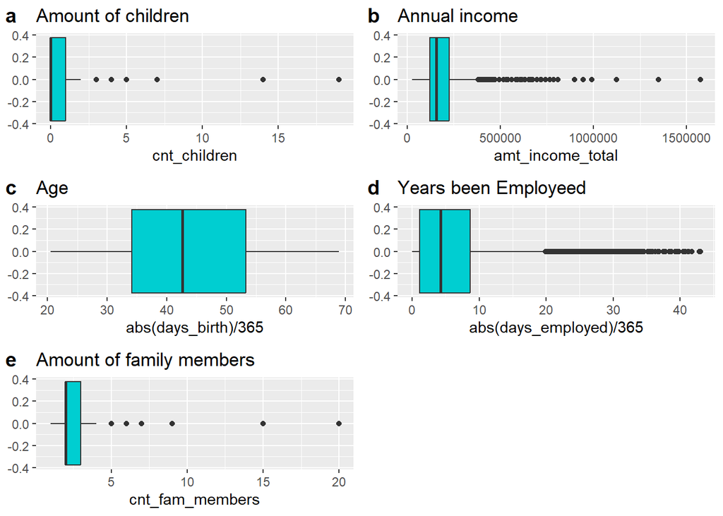

those had been approved’s information (factors - YES/NO)

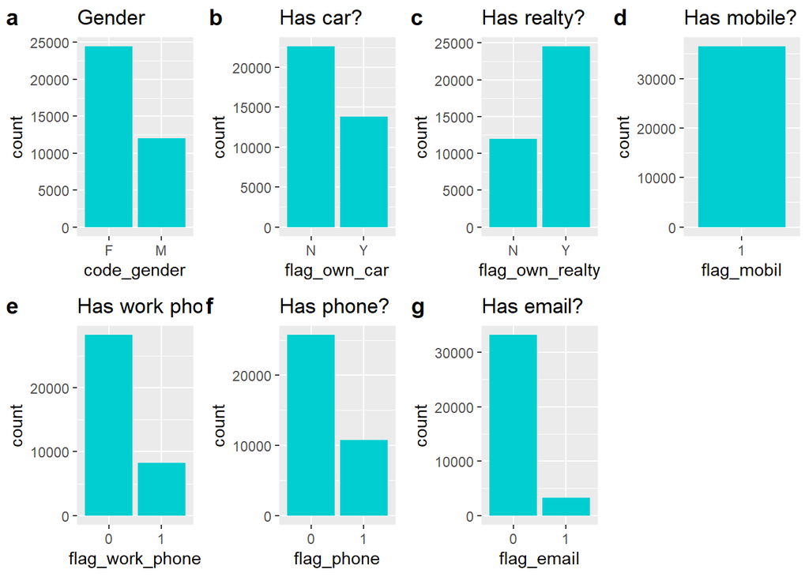

those had been approved’s information (factors - REST)

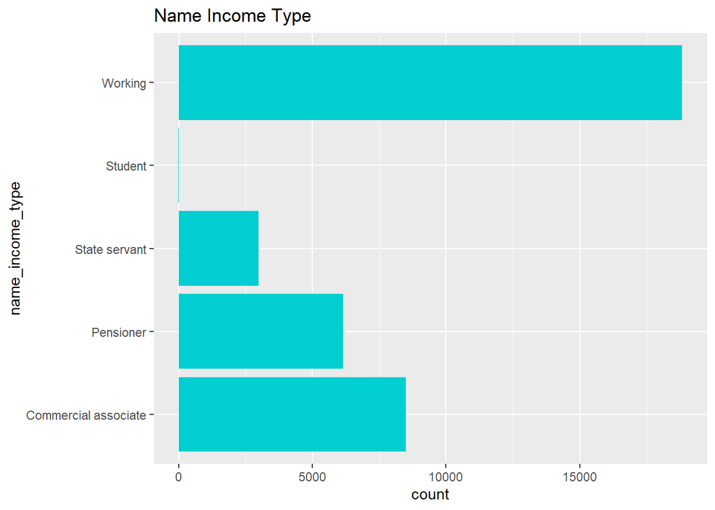

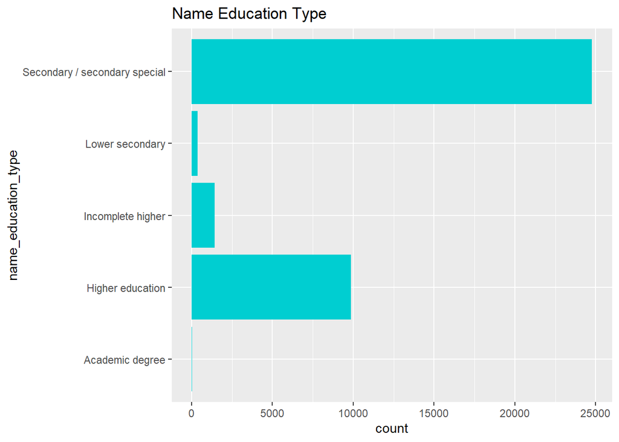

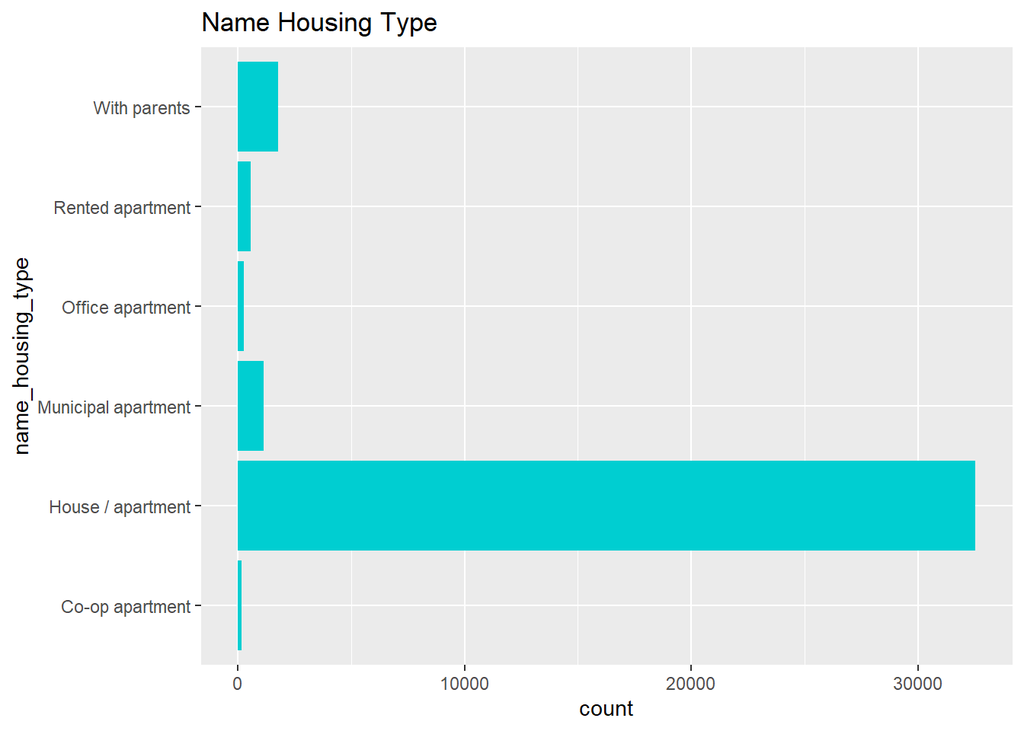

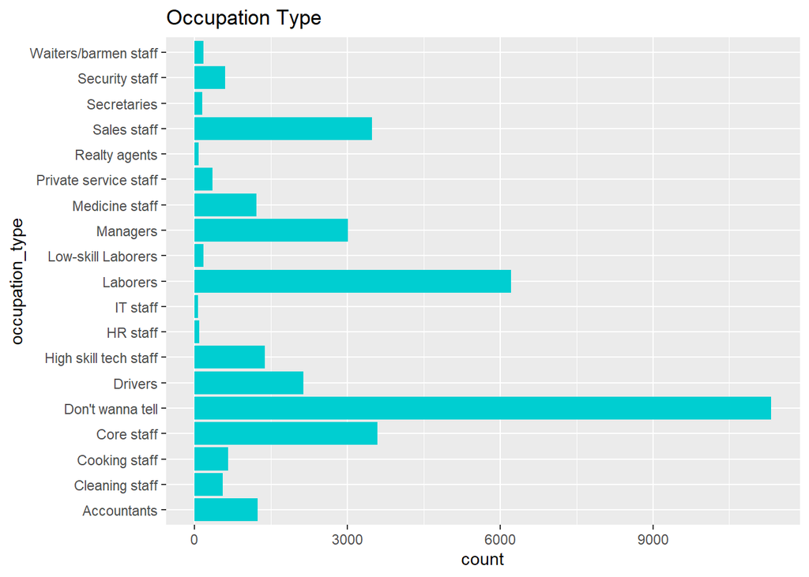

#### Compare numbers of ID

```r
cat(length(unique(first_year_credit$id)),
length(unique(credit$id)),
length(unique(application$id)),
length(unique(first_month$id)))
```

```
## 45985 45985 438510 36457
```

##### My understanding to this data is according to the 45985 people who have credit cards, 36457 people from those 45985 people are applied with recording the backgrounds. The bank issued credit cards to those 36457 people from 438510 applicants.

#### Combine and add our y

```r
mydata1<-application%>%
  filter(! id %in% first_month$id)%>%
  mutate(get_credit_card=FALSE)
mydata2<-application%>%
  filter(id %in% first_month$id)%>%
  mutate(get_credit_card=TRUE)
mydata<-rbind(mydata1,mydata2)
summary(mydata$get_credit_card)
```

```
##    Mode   FALSE    TRUE
## logical  402100   36457
```

There are 402053 people who do not have credit card, while the other 36457 people have.

```r
cat(length(unique(mydata$id)),"is less than",nrow(mydata))
```

```
## 438510 is less than 438557
```

Finding out there are duplicated rows in mydata, since when unique id should be 43510, where we have 438557 rows of mydata, so I remove them:

#### Remove duplicated rows & turn logistics to factors

```r
mydata<-mydata[!duplicated(mydata$id),]
mydata$get_credit_card<-as.factor(mydata$get_credit_card)
```

### An overview of your dataset

What does it include?  
There are two datasets, one is about the information of the applicants who try to get credit card, and the other one is about people’s credit card information. Variables are showing above.  
Where and how will you be obtaining it? Include the link and source.  
About how many observations? How many predictors?  
I will combine two datasets together. My understanding to this data is according to the 45985 people who have credit cards, 36457 people from those 45985 people are applied with recording the backgrounds. The bank issued credit cards to those 36457 people from 438510 applicants. 438510 observations and 18 predictors.  
What types of variables will you be working with?  
Numeric, strings (charactors) and factors.  
Is there any missing data? About how much? Do you have an idea for how to handle it?  
Yes, there are some missing data. The only variable with missingness is occupation_type, which is missing 134203 observations. As it was a string type, so I transfer it to “Dont wanna tell”. There are also many people has 0 employee_day but with number 365243.

### An overview of your research question(s)

What variable(s) are you interested in predicting? What question(s) are you interested in answering?  
The people in credit dataset are who got credit card, where people in application are who applied credit cards. I want to predict what kind of person can successfully get the credit card after application. I want to know which predictor work best.  
Name your response/outcome variable(s) and briefly describe it/them. Will these questions be best answered with a classification or regression approach?  
My response/outcome variable(s) is get_credit_card, it is binary. TRUE means that person successfully applied the credit card, and FALSE means the person fail to be approved. I think these questions be best answered with a classification or regression approach.  
Which predictors do you think will be especially useful?  
I think code_gender,flag_own_car,flag_own_realty,amt_income_total,name_income_type, name_education_type,name_family_status,name_housing_type,cnt_fam_members are important, where the amount of income are most important.  
Is the goal of your model descriptive, predictive, inferential, or a combination? Explain. It is combination. It is predictive as I want to make models predict the TRUE or False for me. And I will also use random forest model to get the best predictor.

### Your proposed project timeline

When do you plan on having your data set loaded, beginning your exploratory data analysis, etc? Provide a general timeline for the rest of the quarter.  
Before November 15th to finish KNN model and logistic Regression. Before the end of November to finish one or more model (include random forest). Finish the rest models and write introduction and conclusion before final week.

### Any questions or concerns

Are there any problems or difficult aspects of the project you anticipate?  
The datasets are too big. It will take time to run for some models. Any specific questions you have for me/the instructional team?  
I do not have any questions yet.